# Statisical Inference - Part 2

For this part we load the **ToothGrowth** data so we can use hypothesis testing to compare tooth growth in each of 10 guinea pigs at each of three dosage levels of Vitamin C (0.5, 1, and 2mg) with each of two delivery methods (orange juice or ascorbic acid).

We expect the data to have 60 observations (10 guinea pigs x 2 delivery m ethods x 3 dosage levels).

The **goal** will be to determine if one dosage level is superior to another, and if one delivery method is superior to another.

First we load the data and perform some basic **exploratory analyses**.

```r
df=data.frame(ToothGrowth)
str(df)
```

```
## 'data.frame':    60 obs. of  3 variables:
##  $ len : num  4.2 11.5 7.3 5.8 6.4 10 11.2 11.2 5.2 7 ...
##  $ supp: Factor w/ 2 levels "OJ","VC": 2 2 2 2 2 2 2 2 2 2 ...
##  $ dose: num  0.5 0.5 0.5 0.5 0.5 0.5 0.5 0.5 0.5 0.5 ...
```

This confirms that we have the 60 cases and that the dataset is organized in the manner we were expecting. Next we compute **means** for length each of the 2 delivery methods and 3 dosage levels.

```r
by(df$len, df$supp, mean)
```

```
## df$supp: OJ
## [1] 20.66333
## --------------------------------------------------------
## df$supp: VC
## [1] 16.96333
```

```r
by(df$len, df$dose, mean)
```

```
## df$dose: 0.5
## [1] 10.605
## --------------------------------------------------------
## df$dose: 1
## [1] 19.735
## --------------------------------------------------------
## df$dose: 2
## [1] 26.1
```

We can see that the mean of length **APPEARS** greater for the OJ method and that it increases as the dosage increases. Next we draw some plots to visualize some of the information.

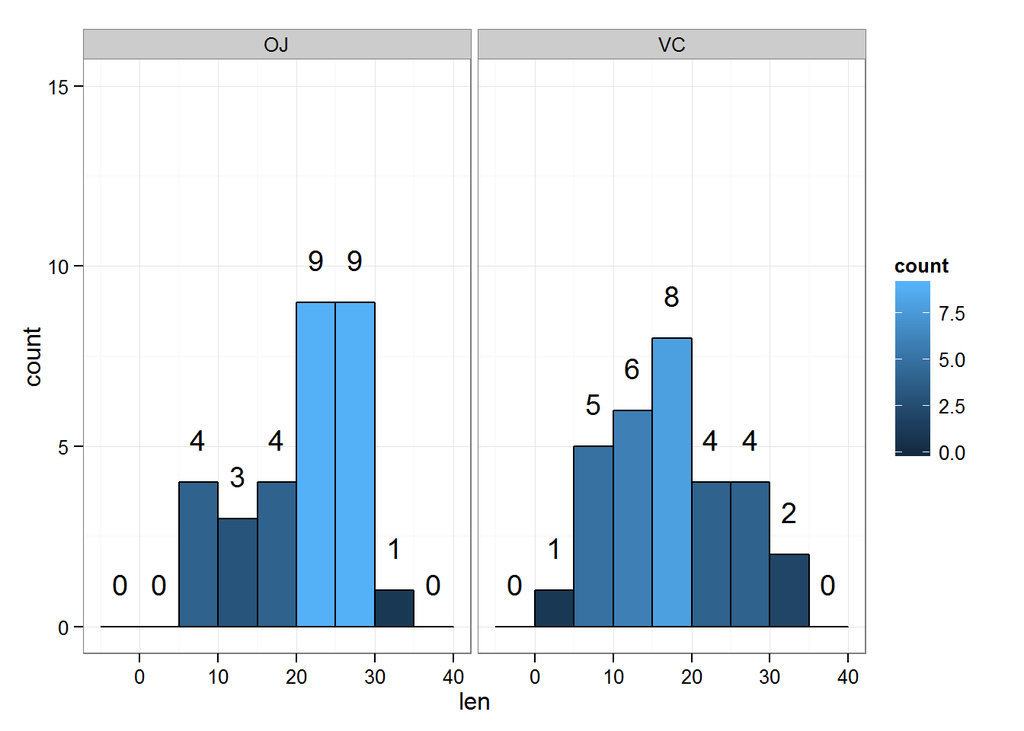

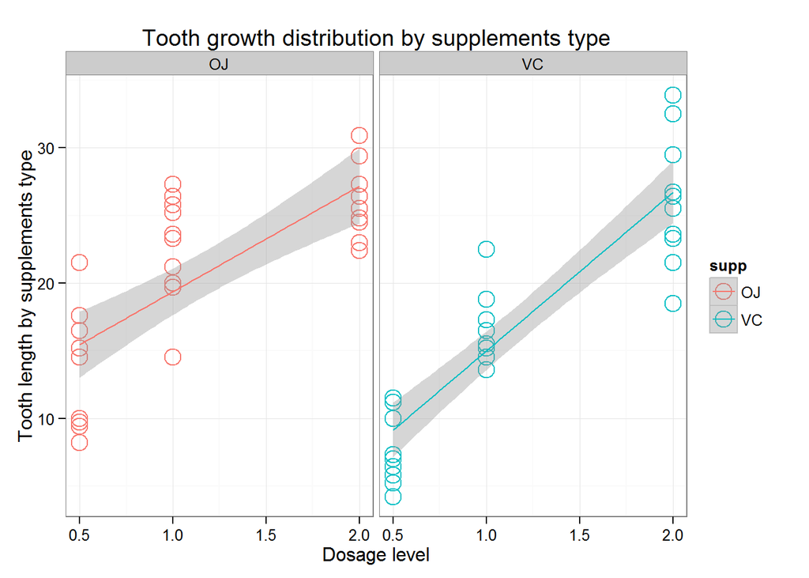

Again, looking at the visual data, the mean of length **APPEARS** greater for the OJ method and that it increases as the dosage increases for both dosage methods. The data also appears to be normally distributed, a key assumption as we move forward.

The next step should be to formally test this. To do this, we make two hypothesis:

1. Mean length is not equal for the OJ and VC delivery methods
2. Mean length is not equal for each of the 3 dosage levels

For both tests we know that the samples are **not paired**, so we will evaluate it as such. **Test 1** can be conducted very simply by doing a t-test at the 95% confidence level for the two delivery methods.

```r
t.test(len ~ supp, data=df)
```

```
##
##  Welch Two Sample t-test
##
## data:  len by supp
## t = 1.9153, df = 55.309, p-value = 0.06063
## alternative hypothesis: true difference in means is not equal to 0
## 95 percent confidence interval:
##  -0.1710156  7.5710156
## sample estimates:
## mean in group OJ mean in group VC
##         20.66333         16.96333
```

The p-value is above 5%, so we fail to reject the null hypothesis that the two means are equal. Thus, we must conclude that the dosage method does not not appear to have an effect here.

For **Test 2** we will have to subset the data so we can perform the right comparisons.

```r
dose1<-subset(ToothGrowth, ToothGrowth$dose %in% c(0.5,1.0))
dose2<-subset(ToothGrowth, ToothGrowth$dose %in% c(2.0,1.0))
dose3<-subset(ToothGrowth, ToothGrowth$dose %in% c(0.5,2.0))

t.test(len ~ dose, paired=FALSE, var.equal=FALSE, data=dose1)
t.test(len ~ dose, paired=FALSE, var.equal=FALSE, data=dose2)
t.test(len ~ dose, paired=FALSE, var.equal=FALSE, data=dose3)
```

The table below has the p-values and t-values for each test. At each one, we see that there is a significant difference between each of the dosage levels. Thus, we can conclude that length increases as the dosage level increases.

The pattern of the results is clear enough that multiple comparison corrections do not seem necessary. Further evidence supporting this decision can be seen in the large t-values.

| Test | P-value | t-value |
| --- | --- | --- |
| 0.5 versus 1.0 | 0.00 | -6.4766477 |
| 2.0 versus 1.0 | 0.00 | -4.9004843 |
| 0.5 versus 2.0 | 0.00 | -11.799046 |